# Week 08: R for Data Analytics (Correlation)

Ziyuan Huang

Last Updated: January 22, 2026

# Introduction

## 1. Overview

This Week 08 tutorial provides a comprehensive, hands-on guide to **correlation analysis** in R. Correlation measures the strength and direction of linear relationships between variables, forming the foundation for more advanced statistical techniques like regression and multivariate analysis. This tutorial upgrades the lecture concepts from `08_correlation.rmd` into practical, code-first workflows:

- **Pearson’s correlation**: For continuous, normally distributed data
- **Spearman’s rho**: For ordinal data or non-normal distributions
- **Kendall’s tau**: Robust alternative for small samples and tied ranks
- **Point-biserial correlation**: For binary variables
- **Partial and semi-partial correlations**: Controlling for third variables
- **Correlation comparisons**: Testing differences between correlations
- **Modern visualization**: Using corrplot, GGally, and ggplot2

> **Reference:** This tutorial draws heavily from Field, Miles, and Field [1], *Discovering Statistics Using R*, particularly Chapter 6 on correlation (pp. 265-298), with IEEE-style citations throughout.

> **Upgrade note:** This hands-on tutorial extends the Week 08 lecture slides in `08_correlation.rmd` with code-first workflows, beginner-friendly explanations, detailed assumptions checking, and modern visualization techniques.

### For Beginners: Quick Start

- **How to run code:**
  - RStudio: place cursor in a chunk, press Ctrl+Enter (Cmd+Enter on Mac) to run; use Knit to render the full document.
  - VS Code: highlight lines and press Ctrl+Enter, or click the Run button above a chunk.
- **Installing packages:** if you see “there is no package called ‘X’”, run `install.packages("X")` once, then `library(X)`.
- **If stuck:** restart R (RStudio: Session → Restart R), then re-run chunks from the top (setup first).
- **Reading errors:** focus on the last lines of the message; they usually state the actual problem (e.g., object not found, package missing, misspelled column).

## 2. Learning Objectives

By the end of this tutorial, you will be able to:

1. Understand the **concept of correlation** and its interpretation as an effect size
2. Calculate **Pearson’s r** for continuous data and interpret confidence intervals
3. Apply **non-parametric correlations** (Spearman, Kendall) for ordinal or non-normal data
4. Create **correlation matrices** with p-values and visualizations
5. Use **point-biserial correlation** for binary variables
6. Compute **partial and semi-partial correlations** to control for confounding
7. **Compare correlations** between independent and dependent samples
8. Create professional **scatterplots and correlation visualizations**
9. Check **assumptions** for correlation analysis
10. Report correlation results in **APA format**

## 3. Required Packages

```r
# Install if needed (uncomment to install)
# install.packages(c("tidyverse", "rio", "ggplot2", "corrplot", "GGally",
#                    "Hmisc", "ppcor", "cocor", "knitr", "kableExtra"))

library(tidyverse)    # Data manipulation and visualization
library(rio)          # Data import
library(ggplot2)      # Advanced plotting
library(corrplot)     # Correlation matrix visualization
library(GGally)       # ggpairs for scatterplot matrices
library(Hmisc)        # rcorr() function
library(ppcor)        # Partial and semi-partial correlations
library(cocor)        # Comparing correlations
library(knitr)        # Table formatting
library(kableExtra)   # Enhanced tables

cat("\n=== REPRODUCIBLE SEED INFORMATION ===")
```

```
##
## === REPRODUCIBLE SEED INFORMATION ===
```

```r
cat("\nGenerator Name: Week08 Correlation Analysis - ANLY500")
```

```
##
## Generator Name: Week08 Correlation Analysis - ANLY500
```

```r
cat("\nMD5 Hash:", gen$get_hash())
```

```
##
## MD5 Hash: 52625c2f4a36d547e76617bfdac4434e
```

```r
cat("\nAvailable Seeds:", paste(seeds[1:5], collapse = ", "), "...\n\n")
```

```
##
## Available Seeds: -353364298, 138287240, -296509229, -988723170, 390809688 ...
```

# Part 1: Understanding Correlation

## 1.1 What is Correlation?

**Correlation** measures the extent to which two variables are linearly related [1, p. 266]. It quantifies both the **direction** (positive or negative) and **strength** (weak to strong) of the relationship.

### Key Concepts:

- **Direction**:
  - **Positive**: As X increases, Y increases (e.g., study time and exam scores)
  - **Negative**: As X increases, Y decreases (e.g., anxiety and performance)
  - **Zero**: No linear relationship
- **Strength**:
  - **r = 0**: No linear relationship
  - **r = ±0.1 to ±0.3**: Small/weak effect
  - **r = ±0.3 to ±0.5**: Medium/moderate effect
  - **r = ±0.5 to ±1.0**: Large/strong effect
  - **r = ±1**: Perfect linear relationship

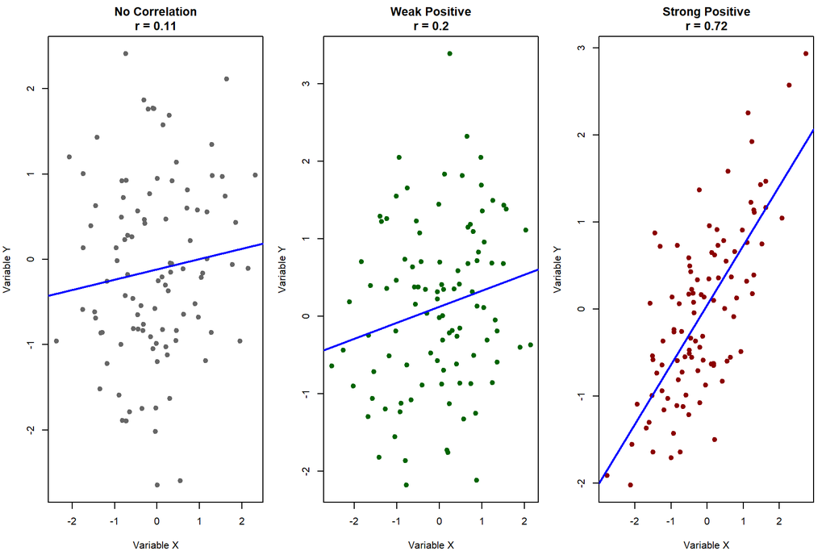

```r
# Generate example data showing different correlations
set.seed(seeds[2])
n <- 100

# Create data with different correlation strengths
data_examples <- data.frame(
  # No correlation (r ≈ 0)
  x_none = rnorm(n),
  y_none = rnorm(n),

  # Positive weak (r ≈ 0.3)
  x_weak = rnorm(n),
  y_weak = 0.3 * rnorm(n) + rnorm(n),

  # Positive strong (r ≈ 0.8)
  x_strong = rnorm(n),
  y_strong = 0.8 * rnorm(n) + 0.2 * rnorm(n)
)

# Actually correlate for weak and strong
data_examples$y_weak <- 0.3 * data_examples$x_weak + sqrt(1 - 0.3^2) * rnorm(n)
data_examples$y_strong <- 0.8 * data_examples$x_strong + sqrt(1 - 0.8^2) * rnorm(n)

# Create plots
par(mfrow = c(1, 3), mar = c(4, 4, 3, 1))

# No correlation
plot(data_examples$x_none, data_examples$y_none,
     main = paste0("No Correlation\nr = ", round(cor(data_examples$x_none, data_examples$y_none), 2)),
     xlab = "Variable X", ylab = "Variable Y", pch = 19, col = "gray40")
abline(lm(y_none ~ x_none, data = data_examples), col = "blue", lwd = 2)

# Weak positive
plot(data_examples$x_weak, data_examples$y_weak,
     main = paste0("Weak Positive\nr = ", round(cor(data_examples$x_weak, data_examples$y_weak), 2)),
     xlab = "Variable X", ylab = "Variable Y", pch = 19, col = "darkgreen")
abline(lm(y_weak ~ x_weak, data = data_examples), col = "blue", lwd = 2)

# Strong positive
plot(data_examples$x_strong, data_examples$y_strong,
     main = paste0("Strong Positive\nr = ", round(cor(data_examples$x_strong, data_examples$y_strong), 2)),
     xlab = "Variable X", ylab = "Variable Y", pch = 19, col = "darkred")
abline(lm(y_strong ~ x_strong, data = data_examples), col = "blue", lwd = 2)
```

```r
par(mfrow = c(1, 1))
```

**Important:** Correlation measures **linear** relationships only. Non-linear relationships (curves) may have low correlation even if variables are strongly related [1, p. 293].

## 1.2 The Correlation Coefficient

The **Pearson product-moment correlation coefficient** (r) is calculated as [1, pp. 268-270]:

$$r = \frac{Cov(x,y)}{s_x s_y} =
\frac{\sum(x_i - \bar{x})(y_i - \bar{y})}{(n-1)s_x s_y}$$

Where: - $Cov(x,y)$ = covariance between X and Y - $s_x$, $s_y$ = standard deviations of X and Y - $\bar{x}$, $\bar{y}$ = means of X and Y

### Understanding Covariance:

**Covariance** measures how two variables vary together [1, p. 268]:

$$Cov(x,y) = \frac{\sum(x_i - \bar{x})(y_i
- \bar{y})}{n-1}$$

- **Positive covariance**: Both variables deviate in the same direction
- **Negative covariance**: Variables deviate in opposite directions
- **Problem**: Scale-dependent (units of measurement affect magnitude)

**Correlation** solves this by standardizing covariance using standard deviations, resulting in values between -1 and +1.

## 1.3 Statistical Significance and Confidence Intervals

### Hypothesis Testing for Correlation

**Null hypothesis** (H₀): ρ = 0 (no linear relationship in population)  
**Alternative hypothesis** (H₁): ρ ≠ 0 (linear relationship exists)

The test statistic follows a t-distribution [1, p. 273]:

$$t =
\frac{r\sqrt{n-2}}{\sqrt{1-r^2}}$$

With degrees of freedom: df = n - 2

### Confidence Intervals

**95% confidence interval** for the correlation coefficient indicates the range where we expect the true population correlation (ρ) to fall with 95% confidence [1, p. 274]. Only `cor.test()` in R provides confidence intervals.

# Part 2: Assumptions for Correlation

Before calculating Pearson’s correlation, verify these assumptions [1, pp. 265-298]:

## 2.1 Assumption Checklist

```r
assumptions <- data.frame(
  Assumption = c("1. Continuous Variables", "2. Independence", "3. Linearity",
                 "4. Homoscedasticity", "5. Normality", "6. No Outliers"),
  Requirement = c(
    "Both variables measured on interval or ratio scale",
    "Observations are independent (not repeated measures)",
    "Relationship is linear, not curved",
    "Equal variance across range of values",
    "Bivariate normality (for significance tests)",
    "No extreme influential cases"
  ),
  Check_Method = c(
    "Verify measurement scales",
    "Check study design",
    "Scatterplot, residual plot",
    "Scatterplot, residual plot",
    "Q-Q plot, histograms, Shapiro-Wilk test",
    "Scatterplot, influence diagnostics"
  ),
  If_Violated = c(
    "Use Spearman or Kendall",
    "Use multilevel modeling",
    "Transform or use Spearman",
    "Transform or use Spearman",
    "Use Spearman or Kendall",
    "Remove or investigate outliers"
  )
)

assumptions %>%
  kable(caption = "Assumptions for Pearson's Correlation [1]") %>%
  kable_styling(bootstrap_options = c("striped", "hover"), full_width = FALSE) %>%
  column_spec(1, bold = TRUE, width = "15em") %>%
  column_spec(2, width = "20em")
```

Assumptions for Pearson’s Correlation [1]

Assumption

Requirement

Check_Method

If_Violated

1. Continuous Variables

Both variables measured on interval or ratio scale

Verify measurement scales

Use Spearman or Kendall

2. Independence

Observations are independent (not repeated measures)

Check study design

Use multilevel modeling

3. Linearity

Relationship is linear, not curved

Scatterplot, residual plot

Transform or use Spearman

4. Homoscedasticity

Equal variance across range of values

Scatterplot, residual plot

Transform or use Spearman

5. Normality

Bivariate normality (for significance tests)

Q-Q plot, histograms, Shapiro-Wilk test

Use Spearman or Kendall

6. No Outliers

No extreme influential cases

Scatterplot, influence diagnostics

Remove or investigate outliers

**Key Point:** If assumptions are violated (especially normality or linearity), use non-parametric alternatives like **Spearman’s rho** or **Kendall’s tau** [1, pp. 277-279].

# Part 3: Correlation Analysis in R

## 3.1 Three Main Functions

R provides three primary functions for correlation analysis [1, pp. 271-276]:

```r
func_table <- data.frame(
  Function = c("cor()", "rcorr()", "cor.test()"),
  Pearson = c("✓", "✓", "✓"),
  Spearman = c("✓", "✓", "✓"),
  Kendall = c("✓", "✗", "✓"),
  Multiple_Vars = c("✓", "✓", "✗"),
  P_values = c("✗", "✓", "✓"),
  Confidence_Interval = c("✗", "✗", "✓"),
  Best_Use = c(
    "Quick exploration",
    "Matrix with p-values",
    "Single pair, full stats"
  )
)

func_table %>%
  kable(caption = "Comparison of R Correlation Functions [1, pp. 271-276]") %>%
  kable_styling(bootstrap_options = c("striped", "hover"), full_width = FALSE) %>%
  column_spec(1, bold = TRUE)
```

Comparison of R Correlation Functions [1, pp. 271-276]

| Function | Pearson | Spearman | Kendall | Multiple_Vars | P_values | Confidence_Interval | Best_Use |
| --- | --- | --- | --- | --- | --- | --- | --- |
| cor() | ✓ | ✓ | ✓ | ✓ | ✗ | ✗ | Quick exploration |
| rcorr() | ✓ | ✓ | ✗ | ✓ | ✓ | ✗ | Matrix with p-values |
| cor.test() | ✓ | ✓ | ✓ | ✗ | ✓ | ✓ | Single pair, full stats |

## 3.2 Load Example Data

We’ll use two datasets from Field et al. [1]:

```r
# Import datasets
exam <- import("data/exam_data.csv")
liar <- import("data/liar_data.csv")

# Examine structure
str(exam)
```

```
## 'data.frame':    103 obs. of  5 variables:
##  $ Code   : int  1 2 3 4 5 6 7 8 9 10 ...
##  $ Revise : int  4 11 27 53 4 22 16 21 25 18 ...
##  $ Exam   : int  40 65 80 80 40 70 20 55 50 40 ...
##  $ Anxiety: num  86.3 88.7 70.2 61.3 89.5 ...
##  $ Gender : int  1 2 1 1 1 2 2 2 2 2 ...
```

```r
str(liar)
```

```
## 'data.frame':    68 obs. of  3 variables:
##  $ Creativity: int  53 36 31 43 30 41 32 54 47 50 ...
##  $ Position  : int  1 3 4 2 4 1 4 1 2 2 ...
##  $ Novice    : chr  "First Time" "Had entered Competition Before" "First Time" "First Time" ...
```

```r
# Summary statistics
summary(exam)
```

```
##       Code           Revise           Exam           Anxiety
##  Min.   :  1.0   Min.   : 0.00   Min.   :  2.00   Min.   : 0.056
##  1st Qu.: 26.5   1st Qu.: 8.00   1st Qu.: 40.00   1st Qu.:69.775
##  Median : 52.0   Median :15.00   Median : 60.00   Median :79.044
##  Mean   : 52.0   Mean   :19.85   Mean   : 56.57   Mean   :74.344
##  3rd Qu.: 77.5   3rd Qu.:23.50   3rd Qu.: 80.00   3rd Qu.:84.686
##  Max.   :103.0   Max.   :98.00   Max.   :100.00   Max.   :97.582
##      Gender
##  Min.   :1.000
##  1st Qu.:1.000
##  Median :1.000
##  Mean   :1.495
##  3rd Qu.:2.000
##  Max.   :2.000
```

```r
summary(liar)
```

```
##    Creativity       Position        Novice
##  Min.   :21.00   Min.   :1.000   Length:68
##  1st Qu.:35.00   1st Qu.:1.000   Class :character
##  Median :39.00   Median :2.000   Mode  :character
##  Mean   :39.99   Mean   :2.221
##  3rd Qu.:45.25   3rd Qu.:3.000
##  Max.   :56.00   Max.   :6.000
```

### Exam Dataset:

- **Exam**: Exam performance score (0-100)
- **Anxiety**: Exam anxiety score
- **Revise**: Time spent revising (hours)
- **Gender**: Student gender (1 = Male, 2 = Female)

### Liar Dataset (World’s Best Liar Competition):

- **Position**: Competition placement (1st, 2nd, 3rd, etc.) - **Ordinal**
- **Creativity**: Creativity questionnaire score (0-60)
- **Novice**: First time vs. returning competitor

# Part 4: Pearson’s Correlation

## 4.1 Single Correlation with cor()

The simplest way to calculate correlation [1, p. 271]:

```r
# Calculate correlation between revision time and exam performance
r_value <- cor(exam$Revise, exam$Exam, use = "complete.obs")
cat("Correlation between Revise and Exam:", round(r_value, 3), "\n")
```

```
## Correlation between Revise and Exam: 0.397
```

```r
# Interpretation
if (abs(r_value) < 0.3) {
  strength <- "weak"
} else if (abs(r_value) < 0.5) {
  strength <- "moderate"
} else {
  strength <- "strong"
}

direction <- ifelse(r_value > 0, "positive", "negative")
cat("This is a", strength, direction, "correlation.\n")
```

```
## This is a moderate positive correlation.
```

**Interpretation:** r = 0.397 indicates a **moderate positive** relationship. Students who spent more time revising tended to perform better on exams [1, p. 266].

## 4.2 Correlation Matrix with cor()

For multiple variables simultaneously:

```r
# Select numeric variables only (exclude Code and Gender for now)
exam_numeric <- exam[, c("Exam", "Anxiety", "Revise")]

# Calculate correlation matrix
cor_matrix <- cor(exam_numeric, use = "pairwise.complete.obs", method = "pearson")
print(round(cor_matrix, 3))
```

```
##           Exam Anxiety Revise
## Exam     1.000  -0.441  0.397
## Anxiety -0.441   1.000 -0.709
## Revise   0.397  -0.709  1.000
```

**Reading the matrix:** - Diagonal values = 1.000 (perfect self-correlation) - `Exam-Anxiety`: r = -0.441 (moderate negative) - `Exam-Revise`: r = 0.397 (moderate positive) - `Anxiety-Revise`: r = -0.709 (strong negative)

## 4.3 Statistical Significance with rcorr()

Add p-values to the correlation matrix [1, p. 272]:

```r
# rcorr() requires matrix input
exam_matrix <- as.matrix(exam_numeric)
result_rcorr <- rcorr(exam_matrix, type = "pearson")

# Display results
cat("=== Correlation Coefficients ===\n")
```

```
## === Correlation Coefficients ===
```

```r
print(round(result_rcorr$r, 3))
```

```
##           Exam Anxiety Revise
## Exam     1.000  -0.441  0.397
## Anxiety -0.441   1.000 -0.709
## Revise   0.397  -0.709  1.000
```

```r
cat("\n=== Sample Sizes ===\n")
```

```
##
## === Sample Sizes ===
```

```r
print(result_rcorr$n)
```

```
##         Exam Anxiety Revise
## Exam     103     103    103
## Anxiety  103     103    103
## Revise   103     103    103
```

```r
cat("\n=== P-values ===\n")
```

```
##
## === P-values ===
```

```r
print(round(result_rcorr$P, 4))
```

```
##         Exam Anxiety Revise
## Exam      NA       0      0
## Anxiety    0      NA      0
## Revise     0       0     NA
```

**Interpreting p-values:** - **p < 0.05**: Statistically significant (reject H₀) - **p ≥ 0.05**: Not significant (fail to reject H₀) - All three correlations are significant (p < 0.05)

## 4.4 Full Statistical Test with cor.test()

For detailed statistics on a single correlation [1, pp. 274-275]:

```r
# Full statistical test
result_test <- cor.test(exam$Revise, exam$Exam,
                        method = "pearson",
                        alternative = "two.sided",
                        conf.level = 0.95)

print(result_test)
```

```
##
##  Pearson's product-moment correlation
##
## data:  exam$Revise and exam$Exam
## t = 4.3434, df = 101, p-value = 3.343e-05
## alternative hypothesis: true correlation is not equal to 0
## 95 percent confidence interval:
##  0.2200938 0.5481602
## sample estimates:
##       cor
## 0.3967207
```

```r
# Extract components
cat("\n=== Interpretation ===\n")
```

```
##
## === Interpretation ===
```

```r
cat("t-statistic:", round(result_test$statistic, 3), "\n")
```

```
## t-statistic: 4.343
```

```r
cat("Degrees of freedom:", result_test$parameter, "\n")
```

```
## Degrees of freedom: 101
```

```r
cat("p-value:", format.pval(result_test$p.value, digits = 3), "\n")
```

```
## p-value: 0
```

```r
cat("Correlation:", round(result_test$estimate, 3), "\n")
```

```
## Correlation: 0.397
```

```r
cat("95% CI: [", round(result_test$conf.int[1], 3), ", ",
    round(result_test$conf.int[2], 3), "]\n", sep = "")
```

```
## 95% CI: [0.22, 0.548]
```

## 4.5 Visualizing Correlations

### Basic Scatterplot

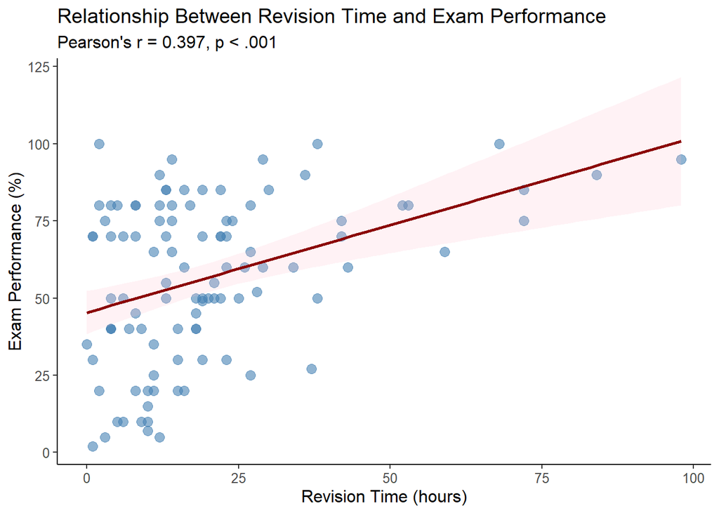

```r
# Define cleanup theme (repository standard)
cleanup <- theme(
  panel.grid.major = element_blank(),
  panel.grid.minor = element_blank(),
  panel.background = element_blank(),
  axis.line.x = element_line(color = "black"),
  axis.line.y = element_line(color = "black"),
  legend.key = element_rect(fill = "white"),
  text = element_text(size = 12)
)

# Create scatterplot
ggplot(exam, aes(x = Revise, y = Exam)) +
  geom_point(size = 3, alpha = 0.6, color = "steelblue") +
  geom_smooth(method = "lm", se = TRUE, color = "darkred", fill = "pink", alpha = 0.2) +
  labs(
    title = "Relationship Between Revision Time and Exam Performance",
    subtitle = paste0("Pearson's r = ", round(r_value, 3), ", p < .001"),
    x = "Revision Time (hours)",
    y = "Exam Performance (%)"
  ) +
  cleanup
```

### Scatterplot Matrix with ggpairs()

Modern approach for multiple variables [1, p. 270]:

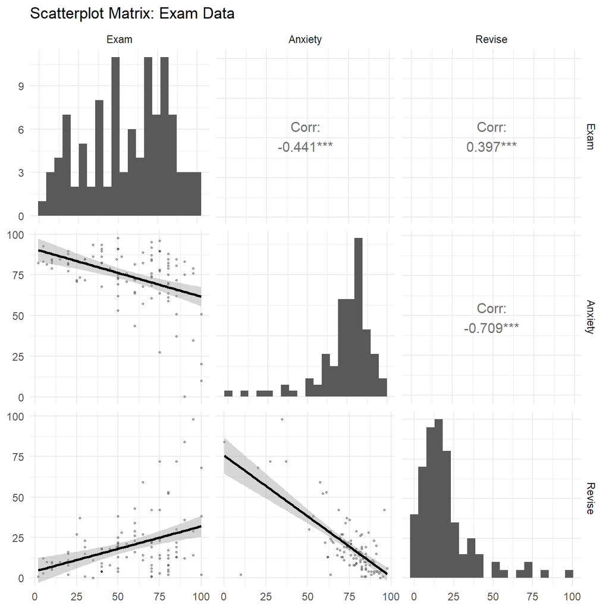

```r
# Create scatterplot matrix
ggpairs(exam_numeric,
        title = "Scatterplot Matrix: Exam Data",
        lower = list(continuous = wrap("smooth", alpha = 0.3, size = 0.5)),
        diag = list(continuous = wrap("barDiag", bins = 20)),
        upper = list(continuous = wrap("cor", size = 4))) +
  theme_minimal()
```

**Reading ggpairs output:** - **Diagonal**: Distribution of each variable - **Lower triangle**: Scatterplots with smoothed lines - **Upper triangle**: Correlation coefficients

### Correlation Heatmap with corrplot()

Professional visualization for correlation matrices:

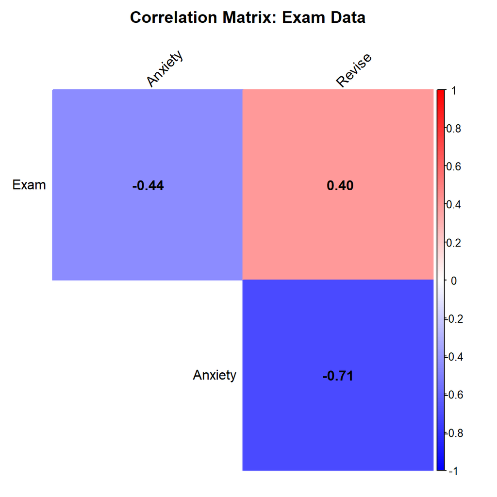

```r
# Create correlation matrix
cor_matrix <- cor(exam_numeric, use = "pairwise.complete.obs")

# Visualize with corrplot
corrplot(cor_matrix,
         method = "color",          # Color-coded cells
         type = "upper",            # Show upper triangle only
         addCoef.col = "black",     # Add correlation coefficients
         tl.col = "black",          # Text label color
         tl.srt = 45,               # Text label rotation (45 degrees)
         diag = FALSE,              # Hide diagonal
         col = colorRampPalette(c("blue", "white", "red"))(200),
         title = "Correlation Matrix: Exam Data",
         mar = c(0, 0, 2, 0))       # Margins
```

# Part 5: Non-Parametric Correlations

## 5.1 When to Use Non-Parametric Methods

Use **Spearman’s rho** or **Kendall’s tau** when [1, pp. 277-279]:

1. **Ordinal data**: Variables are ranks or ordered categories
2. **Non-normal distributions**: Severe violations of normality
3. **Outliers present**: Resistant to extreme values
4. **Small samples**: Especially Kendall’s tau (n < 30)
5. **Tied ranks**: Kendall handles ties better than Spearman

## 5.2 Spearman’s Rho (rs)

**Spearman’s rank correlation** is Pearson’s correlation applied to ranked data [1, p. 277]:

```r
# Spearman's correlation
spearman_result <- cor.test(liar$Creativity, liar$Position, method = "spearman")
print(spearman_result)
```

```
##
##  Spearman's rank correlation rho
##
## data:  liar$Creativity and liar$Position
## S = 71948, p-value = 0.00172
## alternative hypothesis: true rho is not equal to 0
## sample estimates:
##        rho
## -0.3732184
```

```r
cat("\n=== Interpretation ===\n")
```

```
##
## === Interpretation ===
```

```r
cat("Spearman's rho:", round(spearman_result$estimate, 3), "\n")
```

```
## Spearman's rho: -0.373
```

```r
cat("p-value:", format.pval(spearman_result$p.value, digits = 3), "\n")
```

```
## p-value: 0.002
```

**Interpretation:** rs = -0.373, p = .002. More creative liars achieved better (lower numbered) competition positions. This is a **moderate negative** correlation.

## 5.3 Kendall’s Tau (τ)

**Kendall’s tau** is based on concordant vs. discordant pairs [1, pp. 278-279]:

```r
# Kendall's correlation (preferred for ordinal data with ties)
kendall_result <- cor.test(liar$Creativity, liar$Position, method = "kendall")
print(kendall_result)
```

```
##
##  Kendall's rank correlation tau
##
## data:  liar$Creativity and liar$Position
## z = -3.2252, p-value = 0.001259
## alternative hypothesis: true tau is not equal to 0
## sample estimates:
##        tau
## -0.3002413
```

```r
cat("\n=== Interpretation ===\n")
```

```
##
## === Interpretation ===
```

```r
cat("Kendall's tau:", round(kendall_result$estimate, 3), "\n")
```

```
## Kendall's tau: -0.3
```

```r
cat("p-value:", format.pval(kendall_result$p.value, digits = 3), "\n")
```

```
## p-value: 0.001
```

**Interpretation:** τ = -0.300, p = .001. Similar conclusion to Spearman, but more conservative estimate. Field et al. [1, p. 279] recommend Kendall’s tau for ordinal data with tied ranks.

## 5.4 Visualizing Ordinal Relationships

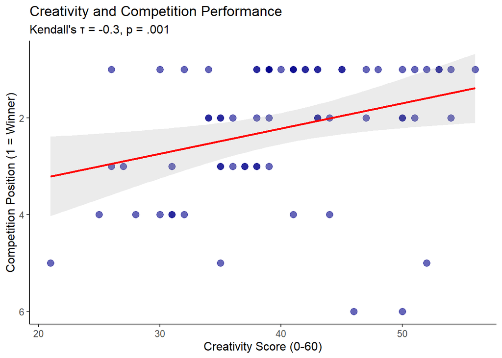

```r
ggplot(liar, aes(x = Creativity, y = Position)) +
  geom_point(size = 3, alpha = 0.6, color = "darkblue") +
  geom_smooth(method = "lm", se = TRUE, color = "red", alpha = 0.2) +
  labs(
    title = "Creativity and Competition Performance",
    subtitle = paste0("Kendall's τ = ", round(kendall_result$estimate, 3), ", p = .001"),
    x = "Creativity Score (0-60)",
    y = "Competition Position (1 = Winner)"
  ) +
  scale_y_reverse() +  # Reverse so winners at top
  cleanup
```

## 5.5 Comparison: Pearson vs. Spearman vs. Kendall

```r
# Calculate all three methods on liar data
pearson_liar <- cor.test(liar$Creativity, liar$Position, method = "pearson")
spearman_liar <- cor.test(liar$Creativity, liar$Position, method = "spearman")
kendall_liar <- cor.test(liar$Creativity, liar$Position, method = "kendall")

comparison <- data.frame(
  Method = c("Pearson", "Spearman", "Kendall"),
  Coefficient = c(
    round(pearson_liar$estimate, 3),
    round(spearman_liar$estimate, 3),
    round(kendall_liar$estimate, 3)
  ),
  P_value = c(
    format.pval(pearson_liar$p.value, digits = 3),
    format.pval(spearman_liar$p.value, digits = 3),
    format.pval(kendall_liar$p.value, digits = 3)
  ),
  Recommendation = c(
    "Use for continuous, normal data",
    "Use for ordinal or non-normal data",
    "Preferred for small samples, tied ranks"
  )
)

comparison %>%
  kable(caption = "Comparison of Correlation Methods on Liar Dataset [1]") %>%
  kable_styling(bootstrap_options = c("striped", "hover"), full_width = FALSE) %>%
  column_spec(1, bold = TRUE)
```

Comparison of Correlation Methods on Liar Dataset [1]

|  | Method | Coefficient | P_value | Recommendation |
| --- | --- | --- | --- | --- |
| cor | Pearson | -0.306 | 0.011 | Use for continuous, normal data |
| rho | Spearman | -0.373 | 0.002 | Use for ordinal or non-normal data |
| tau | Kendall | -0.300 | 0.001 | Preferred for small samples, tied ranks |

**Key finding:** All three methods show negative relationships, but Kendall’s tau is most conservative.

# Part 6: Point-Biserial Correlation

## 6.1 Correlating with Binary Variables

**Point-biserial correlation** measures the relationship between a continuous variable and a true binary variable [1, pp. 280-281]:

- **Point-biserial (rpb)**: Natural dichotomy (e.g., biological sex, alive/dead)
- **Biserial (rb)**: Artificially dichotomized continuous variable (e.g., pass/fail from test score)

### Important Relationships:

1. **Point-biserial correlation = Independent samples t-test**
2. Mathematically equivalent: $r_{pb} = \frac{t}{\sqrt{t^2 + df}}$

```r
# Convert character to numeric
liar$Novice_numeric <- as.numeric(as.factor(liar$Novice))

# Point-biserial correlation
pb_result <- cor.test(liar$Creativity, liar$Novice_numeric)
print(pb_result)
```

```
##
##  Pearson's product-moment correlation
##
## data:  liar$Creativity and liar$Novice_numeric
## t = -2.1969, df = 66, p-value = 0.03154
## alternative hypothesis: true correlation is not equal to 0
## 95 percent confidence interval:
##  -0.47020478 -0.02412131
## sample estimates:
##        cor
## -0.2610451
```

```r
cat("\n=== Interpretation ===\n")
```

```
##
## === Interpretation ===
```

```r
cat("Point-biserial r:", round(pb_result$estimate, 3), "\n")
```

```
## Point-biserial r: -0.261
```

```r
cat("p-value:", format.pval(pb_result$p.value, digits = 3), "\n")
```

```
## p-value: 0.032
```

## 6.2 Visualizing Point-Biserial Correlation

Better visualization with boxplot than scatterplot:

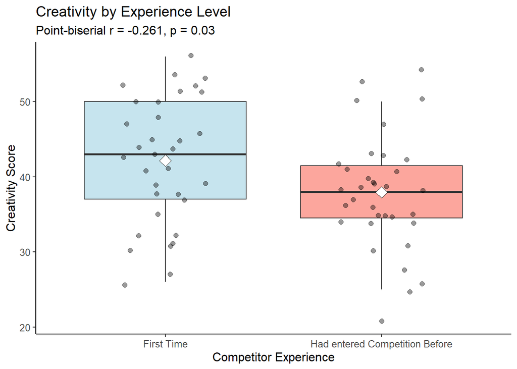

```r
ggplot(liar, aes(x = Novice, y = Creativity, fill = Novice)) +
  geom_boxplot(alpha = 0.7, outlier.shape = NA) +
  geom_jitter(width = 0.2, alpha = 0.4, size = 2) +
  stat_summary(fun = mean, geom = "point", shape = 23, size = 4,
               fill = "white", color = "black") +
  labs(
    title = "Creativity by Experience Level",
    subtitle = paste0("Point-biserial r = ", round(pb_result$estimate, 3),
                     ", p = ", format.pval(pb_result$p.value, digits = 2)),
    x = "Competitor Experience",
    y = "Creativity Score"
  ) +
  scale_fill_manual(values = c("lightblue", "salmon")) +
  cleanup +
  theme(legend.position = "none")
```

## 6.3 Equivalence to t-test

Verify mathematical equivalence:

```r
# Run independent samples t-test
t_result <- t.test(Creativity ~ Novice, data = liar, var.equal = TRUE)
print(t_result)
```

```
##
##  Two Sample t-test
##
## data:  Creativity by Novice
## t = 2.1969, df = 66, p-value = 0.03154
## alternative hypothesis: true difference in means between group First Time and group Had entered Competition Before is not equal to 0
## 95 percent confidence interval:
##  0.383814 8.033502
## sample estimates:
##                     mean in group First Time
##                                     42.15152
## mean in group Had entered Competition Before
##                                     37.94286
```

```r
# Calculate rpb from t-statistic
t_value <- t_result$statistic
df <- t_result$parameter
r_from_t <- t_value / sqrt(t_value^2 + df)

cat("\n=== Equivalence Check ===\n")
```

```
##
## === Equivalence Check ===
```

```r
cat("Point-biserial r:", round(pb_result$estimate, 3), "\n")
```

```
## Point-biserial r: -0.261
```

```r
cat("r calculated from t:", round(r_from_t, 3), "\n")
```

```
## r calculated from t: 0.261
```

```r
cat("Difference:", round(abs(pb_result$estimate - r_from_t), 6), "\n")
```

```
## Difference: 0.52209
```

**Field et al. [1, p. 281]:** t-tests may be more interpretable for binary predictors. Use correlation when part of larger correlation matrix.

# Part 7: Partial and Semi-Partial Correlations

## 7.1 The Third-Variable Problem

**Third-variable problem**: Observed correlation may be due to a confounding variable [1, p. 289]:

- Example: Ice cream sales and drowning deaths are correlated
- Confound: Temperature (hot weather increases both)
- Controlling for temperature removes spurious correlation

## 7.2 Partial Correlation

**Partial correlation (pr)** measures the relationship between X and Y after controlling for Z’s effect on **both X and Y** [1, pp. 289-291]:

$$pr_{XY.Z} = \frac{r_{XY} - r_{XZ} \cdot
r_{YZ}}{\sqrt{(1 - r_{XZ}^2)(1 - r_{YZ}^2)}}$$

```r
# Calculate partial correlations
# Control for all other variables in the dataset
partial_results <- pcor(exam_numeric, method = "pearson")

cat("=== Partial Correlations ===\n")
```

```
## === Partial Correlations ===
```

```r
cat("Controlling for all other variables\n\n")
```

```
## Controlling for all other variables
```

```r
print(round(partial_results$estimate, 3))
```

```
##           Exam Anxiety Revise
## Exam     1.000  -0.247  0.133
## Anxiety -0.247   1.000 -0.649
## Revise   0.133  -0.649  1.000
```

```r
cat("\n=== P-values ===\n")
```

```
##
## === P-values ===
```

```r
print(round(partial_results$p.value, 4))
```

```
##           Exam Anxiety Revise
## Exam    0.0000  0.0124 0.1837
## Anxiety 0.0124  0.0000 0.0000
## Revise  0.1837  0.0000 0.0000
```

## 7.3 Semi-Partial (Part) Correlation

**Semi-partial correlation (sr)** measures the relationship between X and Y after controlling for Z’s effect on **X only** [1, pp. 291-293]:

```r
# Calculate semi-partial correlations
semipartial_results <- spcor(exam_numeric, method = "pearson")

cat("=== Semi-Partial Correlations ===\n")
```

```
## === Semi-Partial Correlations ===
```

```r
cat("Matrix is ASYMMETRIC (upper ≠ lower)\n\n")
```

```
## Matrix is ASYMMETRIC (upper ≠ lower)
```

```r
print(round(semipartial_results$estimate, 3))
```

```
##           Exam Anxiety Revise
## Exam     1.000  -0.226  0.119
## Anxiety -0.174   1.000 -0.582
## Revise   0.094  -0.595  1.000
```

```r
cat("\n=== P-values ===\n")
```

```
##
## === P-values ===
```

```r
print(round(semipartial_results$p.value, 4))
```

```
##           Exam Anxiety Revise
## Exam    0.0000  0.0221 0.2332
## Anxiety 0.0805  0.0000 0.0000
## Revise  0.3498  0.0000 0.0000
```

**Key difference:** Semi-partial matrix is **asymmetric** (upper triangle ≠ lower triangle).

### Use in Regression:

- $sr^2$ = **unique variance** in Y explained by X
- Sum of all $sr^2$ = $R^2$ in multiple regression
- **Field et al. [1, p. 292]**: Essential for understanding unique predictor contributions

## 7.4 Visual Comparison

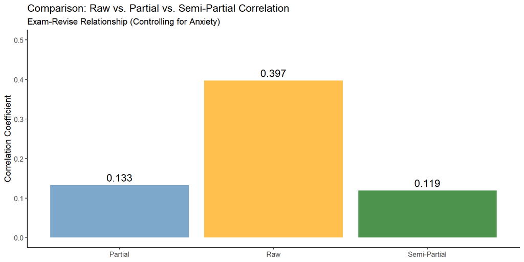

```r
# Get all three correlations
r_raw <- cor(exam$Exam, exam$Revise, use = "complete.obs")
r_partial <- partial_results$estimate[1, 3]  # Exam-Revise
r_semipartial <- semipartial_results$estimate[1, 3]

# Create comparison plot
comparison_data <- data.frame(
  Type = c("Raw", "Partial", "Semi-Partial"),
  Correlation = c(r_raw, r_partial, r_semipartial),
  Description = c(
    "No control",
    "Control Anxiety from both",
    "Control Anxiety from Revise only"
  )
)

ggplot(comparison_data, aes(x = Type, y = Correlation, fill = Type)) +
  geom_col(alpha = 0.7) +
  geom_text(aes(label = round(Correlation, 3)), vjust = -0.5, size = 5) +
  labs(
    title = "Comparison: Raw vs. Partial vs. Semi-Partial Correlation",
    subtitle = "Exam-Revise Relationship (Controlling for Anxiety)",
    x = NULL,
    y = "Correlation Coefficient"
  ) +
  ylim(0, 0.5) +
  scale_fill_manual(values = c("steelblue", "orange", "darkgreen")) +
  cleanup +
  theme(legend.position = "none")
```

# Part 8: Comparing Correlations

## 8.1 Types of Comparisons

The **cocor** package allows testing whether two correlations are significantly different [1, pp. 285-288]:

### Three Types:

1. **Independent correlations**: Different groups, same variables
   - Example: Is r(anxiety, performance) different for men vs. women?
2. **Dependent overlapping**: Same people, shared variable
   - Example: Compare r(X,Y) vs. r(X,Z) in same sample
3. **Dependent non-overlapping**: Same people, different variable pairs
   - Example: Compare r(W,X) vs. r(Y,Z) in same sample

## 8.2 Independent Correlations

Comparing correlations from separate groups [1, p. 285]:

```r
# Split liar data by novice status
first_timers <- subset(liar, Novice == "First Time")
returners <- subset(liar, Novice == "Had entered Competition Before")

# Create list for cocor
ind_data <- list(first_timers, returners)

# Compare correlations between creativity and position
cocor_ind <- cocor(~ Creativity + Position | Creativity + Position,
                   data = ind_data)

print(cocor_ind)
```

```
##
##   Results of a comparison of two correlations based on independent groups
##
## Comparison between r1.jk (Creativity, Position) = -0.2123 and r2.hm (Creativity, Position) = -0.3802
## Difference: r1.jk - r2.hm = 0.1679
## Data: ind_data: j = Creativity, k = Position, h = Creativity, m = Position
## Group sizes: n1 = 33, n2 = 35
## Null hypothesis: r1.jk is equal to r2.hm
## Alternative hypothesis: r1.jk is not equal to r2.hm (two-sided)
## Alpha: 0.05
##
## fisher1925: Fisher's z (1925)
##   z = 0.7268, p-value = 0.4673
##   Null hypothesis retained
##
## zou2007: Zou's (2007) confidence interval
##   95% confidence interval for r1.jk - r2.hm: -0.2792 0.6027
##   Null hypothesis retained (Interval includes 0)
```

**Interpretation:** Tests whether the creativity-position correlation differs between first-timers and returners.

## 8.3 Dependent Overlapping Correlations

Comparing correlations with a shared variable:

```r
# Compare r(Revise, Exam) vs. r(Revise, Anxiety)
# Both correlations share "Revise"
cocor_dep <- cocor(~ Revise + Exam | Revise + Anxiety,
                   data = exam)

print(cocor_dep)
```

```
##
##   Results of a comparison of two overlapping correlations based on dependent groups
##
## Comparison between r.jk (Revise, Exam) = 0.3967 and r.jh (Revise, Anxiety) = -0.7092
## Difference: r.jk - r.jh = 1.106
## Related correlation: r.kh = -0.441
## Data: exam: j = Revise, k = Exam, h = Anxiety
## Group size: n = 103
## Null hypothesis: r.jk is equal to r.jh
## Alternative hypothesis: r.jk is not equal to r.jh (two-sided)
## Alpha: 0.05
##
## pearson1898: Pearson and Filon's z (1898)
##   z = 10.1802, p-value = 0.0000
##   Null hypothesis rejected
##
## hotelling1940: Hotelling's t (1940)
##   t = 9.3238, df = 100, p-value = 0.0000
##   Null hypothesis rejected
##
## williams1959: Williams' t (1959)
##   t = 8.9261, df = 100, p-value = 0.0000
##   Null hypothesis rejected
##
## olkin1967: Olkin's z (1967)
##   z = 10.1802, p-value = 0.0000
##   Null hypothesis rejected
##
## dunn1969: Dunn and Clark's z (1969)
##   z = 8.0684, p-value = 0.0000
##   Null hypothesis rejected
##
## hendrickson1970: Hendrickson, Stanley, and Hills' (1970) modification of Williams' t (1959)
##   t = 9.2710, df = 100, p-value = 0.0000
##   Null hypothesis rejected
##
## steiger1980: Steiger's (1980) modification of Dunn and Clark's z (1969) using average correlations
##   z = 7.6646, p-value = 0.0000
##   Null hypothesis rejected
##
## meng1992: Meng, Rosenthal, and Rubin's z (1992)
##   z = 7.6896, p-value = 0.0000
##   Null hypothesis rejected
##   95% confidence interval for r.jk - r.jh: 0.9727 1.6382
##   Null hypothesis rejected (Interval does not include 0)
##
## hittner2003: Hittner, May, and Silver's (2003) modification of Dunn and Clark's z (1969) using a backtransformed average Fisher's (1921) Z procedure
##   z = 7.6392, p-value = 0.0000
##   Null hypothesis rejected
##
## zou2007: Zou's (2007) confidence interval
##   95% confidence interval for r.jk - r.jh: 0.8698 1.3009
##   Null hypothesis rejected (Interval does not include 0)
```

**Interpretation:** Tests whether revision time is more strongly related to exam performance than to anxiety.

## 8.4 Interpretation Guidelines

```r
interpretation_guide <- data.frame(
  Test = c("Zou's CI", "Dunn & Clark (1969)", "Steiger (1980)", "Fisher's z"),
  Purpose = c(
    "Confidence interval approach",
    "Dependent correlations test",
    "Dependent correlations test (asymptotic)",
    "Independent correlations test"
  ),
  Interpretation = c(
    "If CI excludes 0, correlations differ",
    "p < .05 indicates difference",
    "p < .05 indicates difference",
    "p < .05 indicates difference"
  )
)

interpretation_guide %>%
  kable(caption = "Interpreting cocor Output") %>%
  kable_styling(bootstrap_options = c("striped", "hover"), full_width = FALSE) %>%
  column_spec(1, bold = TRUE)
```

Interpreting cocor Output

| Test | Purpose | Interpretation |
| --- | --- | --- |
| Zou’s CI | Confidence interval approach | If CI excludes 0, correlations differ |
| Dunn & Clark (1969) | Dependent correlations test | p < .05 indicates difference |
| Steiger (1980) | Dependent correlations test (asymptotic) | p < .05 indicates difference |
| Fisher’s z | Independent correlations test | p < .05 indicates difference |

# Part 9: Effect Sizes and Interpretation

## 9.1 Correlation as Effect Size

**Correlation IS an effect size** [1, p. 273]. It represents the proportion of variance shared between variables.

### Cohen’s (1988) Guidelines:

```r
effect_sizes <- data.frame(
  Effect_Size = c("Small", "Medium", "Large"),
  r_Range = c("0.10 - 0.29", "0.30 - 0.49", "0.50 - 1.00"),
  r_squared = c("1% - 8%", "9% - 24%", "25% - 100%"),
  Interpretation = c(
    "Weak relationship",
    "Moderate relationship",
    "Strong relationship"
  )
)

effect_sizes %>%
  kable(caption = "Cohen's Effect Size Guidelines for Correlation [1, p. 273]") %>%
  kable_styling(bootstrap_options = c("striped", "hover"), full_width = FALSE) %>%
  column_spec(1, bold = TRUE)
```

Cohen’s Effect Size Guidelines for Correlation [1, p. 273]

| Effect_Size | r_Range | r_squared | Interpretation |
| --- | --- | --- | --- |
| Small | 0.10 - 0.29 | 1% - 8% | Weak relationship |
| Medium | 0.30 - 0.49 | 9% - 24% | Moderate relationship |
| Large | 0.50 - 1.00 | 25% - 100% | Strong relationship |

**Important:** These are guidelines, not rigid cutoffs! Context matters [1].

## 9.2 Coefficient of Determination (r²)

**r² = proportion of variance in Y explained by X** [1, p. 270]:

```r
# Example: Exam and Revise
r_exam_revise <- cor(exam$Revise, exam$Exam, use = "complete.obs")
r_squared <- r_exam_revise^2

cat("=== Coefficient of Determination ===\n")
```

```
## === Coefficient of Determination ===
```

```r
cat("Correlation (r):", round(r_exam_revise, 3), "\n")
```

```
## Correlation (r): 0.397
```

```r
cat("r²:", round(r_squared, 3), "\n")
```

```
## r²: 0.157
```

```r
cat("Interpretation:", round(r_squared * 100, 1), "% of variance in exam scores\n")
```

```
## Interpretation: 15.7 % of variance in exam scores
```

```r
cat("                is explained by revision time.\n")
```

```
##                 is explained by revision time.
```

### Visualizing Shared Variance:

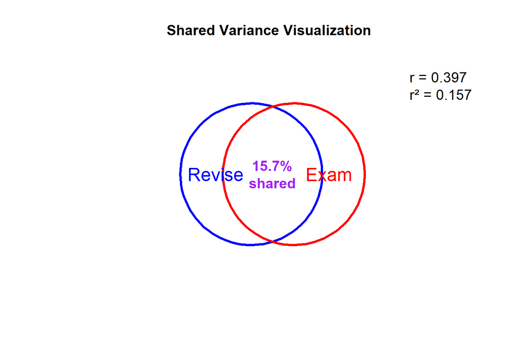

```r
# Create data for Venn diagram simulation
set.seed(seeds[3])
circle_points <- 100
theta <- seq(0, 2*pi, length.out = circle_points)

# Two circles representing variables
circle1_x <- cos(theta)
circle1_y <- sin(theta)
circle2_x <- cos(theta) + 0.6  # Overlap based on r = 0.397
circle2_y <- sin(theta)

plot(circle1_x, circle1_y, type = "l", lwd = 3, col = "blue",
     xlim = c(-1.5, 2), ylim = c(-1.5, 1.5),
     xlab = "", ylab = "", main = "Shared Variance Visualization",
     asp = 1, axes = FALSE)
lines(circle2_x, circle2_y, lwd = 3, col = "red")

# Add labels
text(-0.5, 0, "Revise", cex = 1.5, col = "blue")
text(1.1, 0, "Exam", cex = 1.5, col = "red")
text(0.3, 0, paste0(round(r_squared * 100, 1), "%\nshared"),
     cex = 1.2, col = "purple", font = 2)

# Add legend
legend("topright",
       legend = c(paste0("r = ", round(r_exam_revise, 3)),
                 paste0("r² = ", round(r_squared, 3))),
       bty = "n", cex = 1.2)
```

**Interpretation:** Only 16% of exam performance variance is explained by revision time. 84% is due to other factors (ability, anxiety, luck, etc.).